TITANIC

# Carica i file dal tuo computer

```python
# Importa le librerie necessarie
    import pandas as pd


    # Leggi il dataset
    dataset = pd.read_csv("./titanic.csv")

    # Mostra le prime righe del dataset per comprendere la struttura
    dataset.head()
```

|  | PassengerId | Survived | Pclass | Name | Sex | Age | SibSp | Parch | Ticket | Fare | Cabin | Embarked |
| --- | --- | --- | --- | --- | --- | --- | --- | --- | --- | --- | --- | --- |
| 0 | 1 | 0 | 3 | Braund, Mr. Owen Harris | male | 22.0 | 1 | 0 | A/5 21171 | 7.2500 | NaN | S |
| 1 | 2 | 1 | 1 | Cumings, Mrs. John Bradley (Florence Briggs Th... | female | 38.0 | 1 | 0 | PC 17599 | 71.2833 | C85 | C |
| 2 | 3 | 1 | 3 | Heikkinen, Miss. Laina | female | 26.0 | 0 | 0 | STON/O2. 3101282 | 7.9250 | NaN | S |
| 3 | 4 | 1 | 1 | Futrelle, Mrs. Jacques Heath (Lily May Peel) | female | 35.0 | 1 | 0 | 113803 | 53.1000 | C123 | S |
| 4 | 5 | 0 | 3 | Allen, Mr. William Henry | male | 35.0 | 0 | 0 | 373450 | 8.0500 | NaN | S |

# Importazione delle librerie necessarie

Importiamo le librerie per la manipolazione dei dati (pandas e numpy) e per le visualizzazioni grafiche (matplotlib e seaborn).

```python
# Cell 1: Importazione delle librerie necessarie
    # Importiamo le librerie per la manipolazione dei dati (pandas e numpy)
    # e per le visualizzazioni grafiche (matplotlib e seaborn).
    import pandas as pd
    import numpy as np
    import matplotlib.pyplot as plt
    import seaborn as sns
    import warnings

    # Ignora i warning
    warnings.filterwarnings("ignore")

    # Configuriamo lo stile dei grafici per renderli più leggibili
    plt.style.use('ggplot')
    plt.rcParams['figure.figsize'] = (10, 6)  # Imposta la dimensione delle figure
```

# Informazioni di base sul dataset

```python
# Cell 3: Informazioni di base sul dataset
    # Stampiamo le dimensioni del dataset (numero di righe e colonne) e le informazioni generali
    print("Dimensioni del dataset:", dataset.shape)  # Dimensioni del dataset
    dataset.info()  # Informazioni generali su tipi di dati e conteggio dei valori non nulli

    # Calcoliamo il numero di valori mancanti per ogni colonna
    missing_values = dataset.isnull().sum()
    missing_values[missing_values > 0]  # Mostriamo solo le colonne con valori mancanti
```

```
Dimensioni del dataset: (891, 12)
    <class 'pandas.core.frame.DataFrame'>
    RangeIndex: 891 entries, 0 to 890
    Data columns (total 12 columns):
     #   Column       Non-Null Count  Dtype
    ---  ------       --------------  -----
     0   PassengerId  891 non-null    int64
     1   Survived     891 non-null    int64
     2   Pclass       891 non-null    int64
     3   Name         891 non-null    object
     4   Sex          891 non-null    object
     5   Age          714 non-null    float64
     6   SibSp        891 non-null    int64
     7   Parch        891 non-null    int64
     8   Ticket       891 non-null    object
     9   Fare         891 non-null    float64
     10  Cabin        204 non-null    object
     11  Embarked     889 non-null    object
    dtypes: float64(2), int64(5), object(5)
    memory usage: 83.7+ KB
```

```
Age         177
    Cabin       687
    Embarked      2
    dtype: int64
```

# Statistiche descrittive

```python
# Cell 4: Statistiche descrittive
    # Generiamo statistiche descrittive (media, deviazione standard, min, max, ecc.) per tutte le variabili numeriche
    dataset.describe()
```

|  | PassengerId | Survived | Pclass | Age | SibSp | Parch | Fare |
| --- | --- | --- | --- | --- | --- | --- | --- |
| count | 891.000000 | 891.000000 | 891.000000 | 714.000000 | 891.000000 | 891.000000 | 891.000000 |
| mean | 446.000000 | 0.383838 | 2.308642 | 29.699118 | 0.523008 | 0.381594 | 32.204208 |
| std | 257.353842 | 0.486592 | 0.836071 | 14.526497 | 1.102743 | 0.806057 | 49.693429 |
| min | 1.000000 | 0.000000 | 1.000000 | 0.420000 | 0.000000 | 0.000000 | 0.000000 |
| 25% | 223.500000 | 0.000000 | 2.000000 | 20.125000 | 0.000000 | 0.000000 | 7.910400 |
| 50% | 446.000000 | 0.000000 | 3.000000 | 28.000000 | 0.000000 | 0.000000 | 14.454200 |
| 75% | 668.500000 | 1.000000 | 3.000000 | 38.000000 | 1.000000 | 0.000000 | 31.000000 |
| max | 891.000000 | 1.000000 | 3.000000 | 80.000000 | 8.000000 | 6.000000 | 512.329200 |

# Analisi delle variabili categoriche

Identifichiamo le colonne con dati categorici e visualizziamo il conteggio di ciascuna categoria. Questo ci aiuta a capire meglio la distribuzione delle categorie.

```python
# Cell 5: Analisi delle variabili categoriche
    # Identifichiamo le colonne con dati categorici e visualizziamo il conteggio di ciascuna categoria.
    # Questo ci aiuta a capire meglio la distribuzione delle categorie.
    categorical_columns = dataset.select_dtypes(include=['object']).columns  # Trova le colonne categoriche
    for column in categorical_columns:
        print(f"Conteggio valori per la colonna '{column}':")
        print(dataset[column].value_counts())  # Conteggio dei valori per ogni categoria
        print("\n")
```

```
Conteggio valori per la colonna 'Name':
    Name
    Braund, Mr. Owen Harris                     1
    Boulos, Mr. Hanna                           1
    Frolicher-Stehli, Mr. Maxmillian            1
    Gilinski, Mr. Eliezer                       1
    Murdlin, Mr. Joseph                         1
                                               ..
    Kelly, Miss. Anna Katherine "Annie Kate"    1
    McCoy, Mr. Bernard                          1
    Johnson, Mr. William Cahoone Jr             1
    Keane, Miss. Nora A                         1
    Dooley, Mr. Patrick                         1
    Name: count, Length: 891, dtype: int64


    Conteggio valori per la colonna 'Sex':
    Sex
    male      577
    female    314
    Name: count, dtype: int64


    Conteggio valori per la colonna 'Ticket':
    Ticket
    347082      7
    CA. 2343    7
    1601        7
    3101295     6
    CA 2144     6
               ..
    9234        1
    19988       1
    2693        1
    PC 17612    1
    370376      1
    Name: count, Length: 681, dtype: int64


    Conteggio valori per la colonna 'Cabin':
    Cabin
    B96 B98        4
    G6             4
    C23 C25 C27    4
    C22 C26        3
    F33            3
                  ..
    E34            1
    C7             1
    C54            1
    E36            1
    C148           1
    Name: count, Length: 147, dtype: int64


    Conteggio valori per la colonna 'Embarked':
    Embarked
    S    644
    C    168
    Q     77
    Name: count, dtype: int64
```

# Analisi delle distribuzioni per le variabili numeriche

Creiamo istogrammi per ogni variabile numerica per visualizzare la distribuzione dei dati

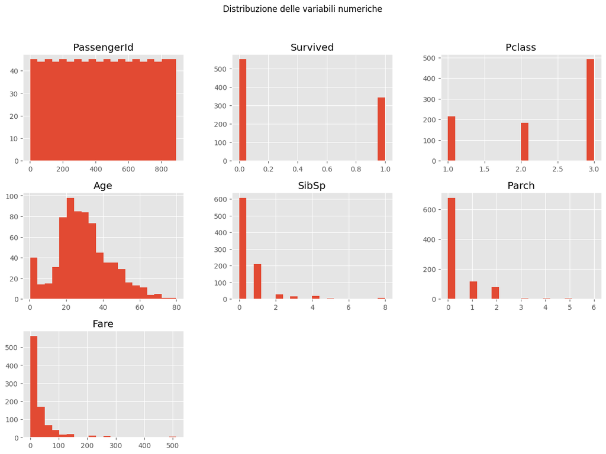

```python
# Cell 6: Analisi delle distribuzioni per le variabili numeriche
    # Creiamo istogrammi per ogni variabile numerica per visualizzare la distribuzione dei dati
    numerical_columns = dataset.select_dtypes(include=[np.number]).columns  # Trova le colonne numeriche
    dataset[numerical_columns].hist(bins=20, figsize=(15, 10))  # Istogrammi con 15 bin per ogni variabile numerica
    plt.suptitle("Distribuzione delle variabili numeriche")  # Titolo generale per tutti gli istogrammi
    plt.show()
```

# Box plot per individuare possibili outliers

Generiamo un box plot per ogni variabile numerica per visualizzare gli outliers

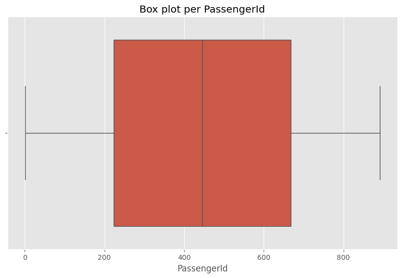

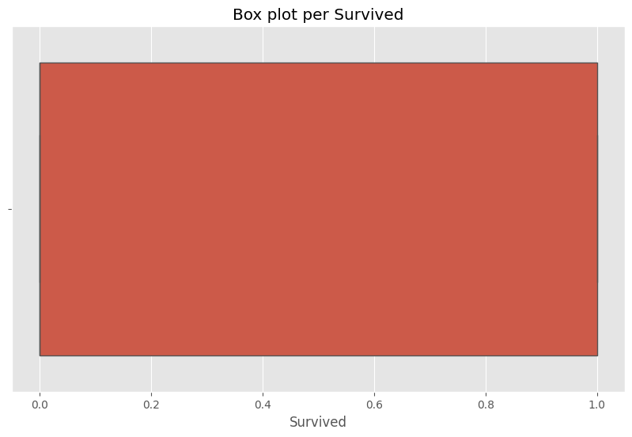

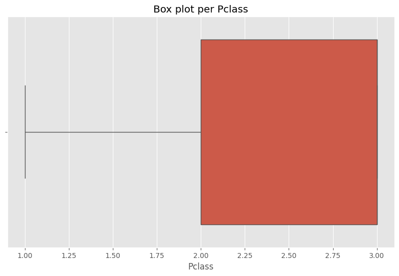

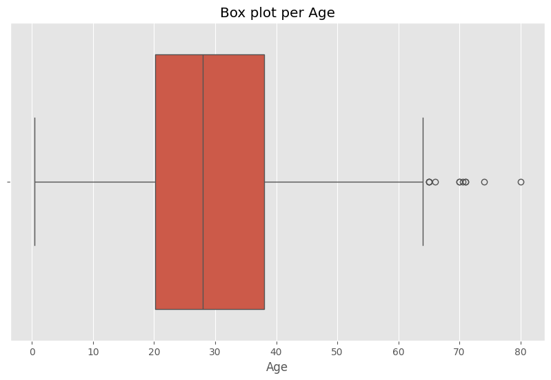

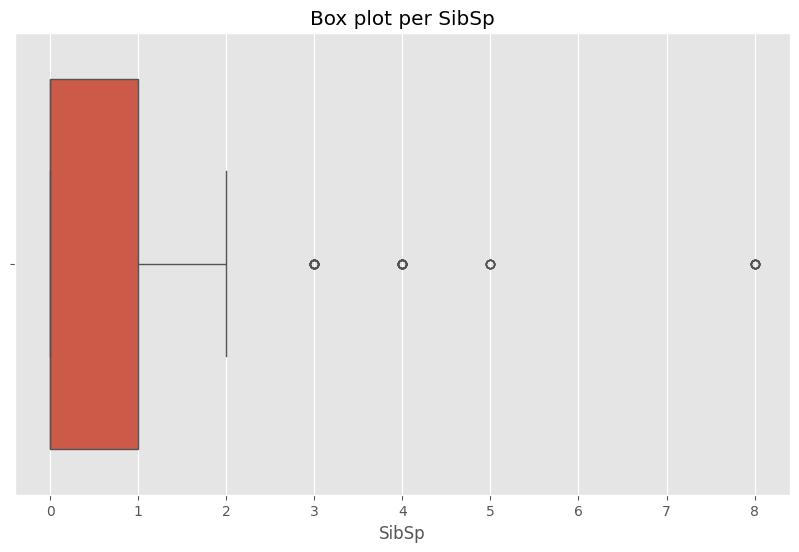

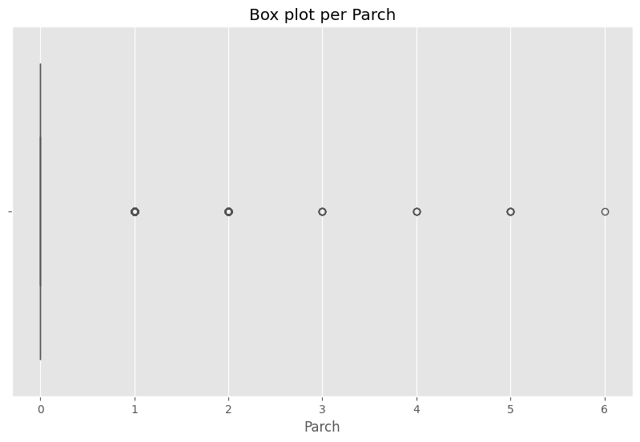

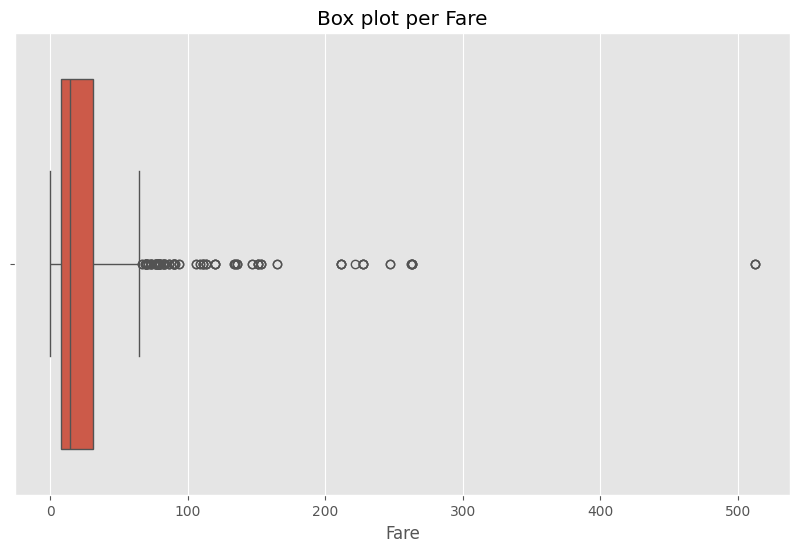

```python
# Cell 7: Box plot per individuare possibili outliers

    for column in numerical_columns:
        plt.figure()
        sns.boxplot(x= dataset[column])  # Box plot per la colonna attuale
        plt.title(f"Box plot per {column}")  # Titolo per il grafico attuale
        plt.show()
```

Chi sono gli outliers?

```python
# Funzione per trovare gli outliers
    def trova_outliers(dataset, colonna):
        q1 = dataset[colonna].quantile(0.25)
        q3 = dataset[colonna].quantile(0.75)
        iqr = q3 - q1
        lower_bound = q1 - 1.5 * iqr
        upper_bound = q3 + 1.5 * iqr
        return dataset[(dataset[colonna] < lower_bound) | (dataset[colonna] > upper_bound)]

    # Trova gli outliers nella colonna "Partite_giocate"
    outliers = trova_outliers(dataset, 'Age')

    # Stampa i nomi dei giocatori con outliers
    print("Giocatori con valori outlier:")
    print(outliers['Name'].tolist())
```

[output not shown]

Trasformo vi valori Outliers nella media

```python
# Funzione per sostituire gli outliers con la media
    def sostituisci_outlier_con_media(dataset, colonna):
        q1 = dataset[colonna].quantile(0.25)
        q3 = dataset[colonna].quantile(0.75)
        iqr = q3 - q1
        lower_bound = q1 - 1.5 * iqr
        upper_bound = q3 + 1.5 * iqr
        media_senza_outlier = dataset[colonna][(dataset[colonna] >= lower_bound) & (dataset[colonna] <= upper_bound)].mean()
        dataset[colonna] = dataset[colonna].apply(lambda x: media_senza_outlier if x < lower_bound or x > upper_bound else x)

    # Sostituisci gli outliers con la media nella colonna "Partite_giocate"
    sostituisci_outlier_con_media(dataset, 'Age')

    # Verifica del dataset aggiornato
    print("Dataset aggiornato con outliers sostituiti:")
    print(dataset.head())
```

```
Dataset aggiornato con outliers sostituiti:
       PassengerId  Survived  Pclass  \
    0            1         0       3
    1            2         1       1
    2            3         1       3
    3            4         1       1
    4            5         0       3

                                                    Name     Sex   Age  SibSp  \
    0                            Braund, Mr. Owen Harris    male  22.0      1
    1  Cumings, Mrs. John Bradley (Florence Briggs Th...  female  38.0      1
    2                             Heikkinen, Miss. Laina  female  26.0      0
    3       Futrelle, Mrs. Jacques Heath (Lily May Peel)  female  35.0      1
    4                           Allen, Mr. William Henry    male  35.0      0

       Parch            Ticket     Fare Cabin Embarked
    0      0         A/5 21171   7.2500   NaN        S
    1      0          PC 17599  71.2833   C85        C
    2      0  STON/O2. 3101282   7.9250   NaN        S
    3      0            113803  53.1000  C123        S
    4      0            373450   8.0500   NaN        S
```

# Correlazioni e Correlogramma

Filtriamo solo le colonne numeriche per calcolare la matrice di correlazion

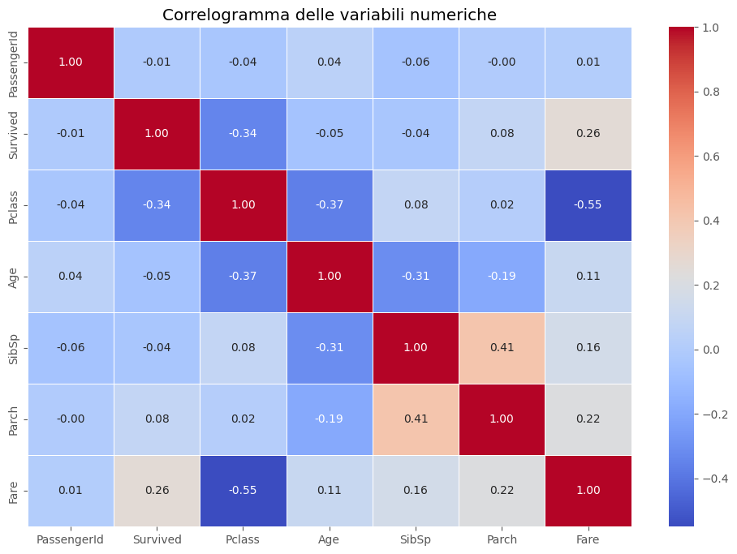

```python
# Cell 8: Correlazioni e Correlogramma
    # Filtriamo solo le colonne numeriche per calcolare la matrice di correlazione
    numerical_dataset = dataset.select_dtypes(include=[np.number])  # Seleziona solo le colonne numeriche
    correlation_matrix = numerical_dataset.corr()  # Calcoliamo la matrice di correlazione

    # Visualizziamo la matrice di correlazione con una heatmap
    plt.figure(figsize=(12, 8))  # Imposta la dimensione della figura
    sns.heatmap(correlation_matrix, annot=True, cmap="coolwarm", fmt=".2f", linewidths=0.5)  # Heatmap con annotazioni
    plt.title("Correlogramma delle variabili numeriche")  # Titolo per la heatmap
    plt.show()
```

# Analisi Cluster (Unsupervised)

calcolo il numero di Cluster con metodo Elbow

Il metodo Elbow aiuta a trovare il giusto compromesso tra semplicità del modello e accuratezza, scegliendo 𝑘 k dove il miglioramento della performance diminuisce drasticamente.

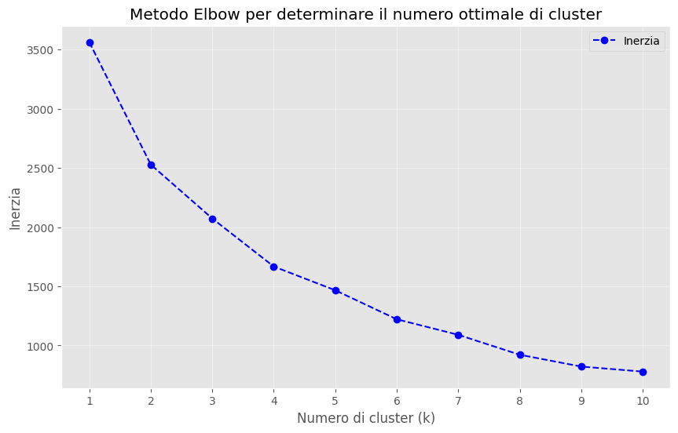

```python
from sklearn.cluster import KMeans
    from sklearn.preprocessing import StandardScaler
    from sklearn.impute import SimpleImputer
    import matplotlib.pyplot as plt
    import pandas as pd

    # Supponiamo che 'dataset' sia già definito
    variabili = dataset.columns.tolist()[3:]

    # Seleziona solo le colonne numeriche
    variabili_numeriche = dataset[variabili].select_dtypes(include=['float64', 'int64']).columns.tolist()

    # Usare un imputer per gestire i valori NaN
    imputer = SimpleImputer(strategy='mean')
    dati_filled = imputer.fit_transform(dataset[variabili_numeriche])

    # Standardizzare le variabili
    scaler = StandardScaler()
    dati_scalati = scaler.fit_transform(dati_filled)

    # Calcolare l'inerzia per diversi valori di k
    inerzia = []
    valori_k = range(1, 11)  # Proviamo da 1 a 10 cluster

    for k in valori_k:
        kmeans = KMeans(n_clusters=k, random_state=42)
        kmeans.fit(dati_scalati)
        inerzia.append(kmeans.inertia_)

    # Tracciare il grafico del metodo Elbow
    plt.figure(figsize=(10, 6))
    plt.plot(valori_k, inerzia, marker='o', linestyle='--', color='b', label='Inerzia')
    plt.xlabel('Numero di cluster (k)')
    plt.ylabel('Inerzia')
    plt.title('Metodo Elbow per determinare il numero ottimale di cluster')
    plt.xticks(valori_k)
    plt.legend()
    plt.grid(alpha=0.4)
    plt.show()
```

```
   PassengerId  Survived  Pclass  \
    0            1         0       3
    1            2         1       1
    2            3         1       3
    3            4         1       1
    4            5         0       3

                                                    Name     Sex   Age  SibSp  \
    0                            Braund, Mr. Owen Harris    male  22.0      1
    1  Cumings, Mrs. John Bradley (Florence Briggs Th...  female  38.0      1
    2                             Heikkinen, Miss. Laina  female  26.0      0
    3       Futrelle, Mrs. Jacques Heath (Lily May Peel)  female  35.0      1
    4                           Allen, Mr. William Henry    male  35.0      0

       Parch            Ticket     Fare Cabin Embarked
    0      0         A/5 21171   7.2500   NaN        S
    1      0          PC 17599  71.2833   C85        C
    2      0  STON/O2. 3101282   7.9250   NaN        S
    3      0            113803  53.1000  C123        S
    4      0            373450   8.0500   NaN        S
    Cluster
    1    466
    0    248
    Name: count, dtype: int64
```

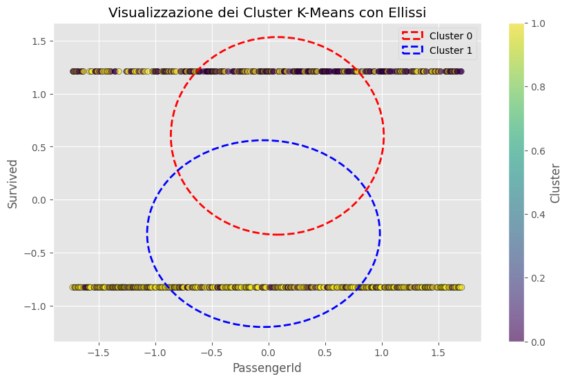

```
    Caratteristiche distintive di ogni cluster:

             PassengerId  Survived    Pclass        Age     SibSp     Parch  \
    Cluster
    0         469.177419  0.701613  1.254032  37.396583  0.443548  0.403226
    1         437.622318  0.248927  2.759657  24.641868  0.549356  0.446352

                  Fare
    Cluster
    0        71.125925
    1        15.306124

    Caratteristiche del Cluster 0:
     - PassengerId: 469.18
     - Survived: 0.70
     - Pclass: 1.25
     - Age: 37.40
     - SibSp: 0.44
     - Parch: 0.40
     - Fare: 71.13

    Caratteristiche del Cluster 1:
     - PassengerId: 437.62
     - Survived: 0.25
     - Pclass: 2.76
     - Age: 24.64
     - SibSp: 0.55
     - Parch: 0.45
     - Fare: 15.31
```

```python
# Importare le librerie necessarie
    import pandas as pd
    import numpy as np
    import matplotlib.pyplot as plt
    from sklearn.cluster import KMeans
    from sklearn.preprocessing import StandardScaler
    from matplotlib.patches import Ellipse

    # Visualizzare le prime righe del dataset per capire la struttura
    print(dataset.head())

    # Selezionare solo le colonne numeriche
    variabili = dataset.select_dtypes(include=[np.number]).columns.tolist()

    # Rimuovere le righe con valori NaN
    dataset_clean = dataset.dropna(subset=variabili)

    # Standardizzare le variabili
    scaler = StandardScaler()
    dati_scalati = scaler.fit_transform(dataset_clean[variabili])

    # Creazione del modello K-Means con k=2
    kmeans = KMeans(n_clusters=2, random_state=42)

    # Adattare il modello ai dati scalati
    kmeans.fit(dati_scalati)

    # Aggiungere i cluster al dataset originale
    dataset_clean['Cluster'] = kmeans.labels_

    # Visualizzare la distribuzione dei cluster
    print(dataset_clean['Cluster'].value_counts())

    # Visualizzare i cluster utilizzando due variabili a scopo esemplificativo
    plt.figure(figsize=(10, 6))
    plt.scatter(dati_scalati[:, 0], dati_scalati[:, 1], c=kmeans.labels_, cmap='viridis', alpha=0.6, edgecolor='k')
    plt.xlabel(variabili[0])
    plt.ylabel(variabili[1])
    plt.title('Visualizzazione dei Cluster K-Means con Ellissi')
    plt.colorbar(label='Cluster')

    # Evidenziare i cluster con un perimetro (utilizzando ellissi attorno ai dati) con colori differenti per ogni cluster
    centroidi = kmeans.cluster_centers_
    colori_ellissi = ['red', 'blue']
    for i in range(2):
        punti_cluster = dati_scalati[kmeans.labels_ == i]
        ellisse = Ellipse(xy=(np.mean(punti_cluster[:, 0]), np.mean(punti_cluster[:, 1])),
                          width=2 * np.std(punti_cluster[:, 0]),
                          height=2 * np.std(punti_cluster[:, 1]),
                          edgecolor=colori_ellissi[i], fc='None', lw=2, linestyle='--', label=f'Cluster {i}')
        plt.gca().add_patch(ellisse)

    plt.legend()
    plt.show()

    # Calcolare la media delle variabili per ogni cluster
    caratteristiche_cluster = dataset_clean.groupby('Cluster')[variabili].mean()

    # Visualizzare le caratteristiche distintive di ogni cluster
    print("\nCaratteristiche distintive di ogni cluster:\n")
    print(caratteristiche_cluster)

    # Spiegazione in forma di testo delle caratteristiche di ogni cluster
    for i in range(2):
        print(f"\nCaratteristiche del Cluster {i}:")
        for variabile in variabili:
            valore = caratteristiche_cluster.loc[i, variabile]
            print(f" - {variabile}: {valore:.2f}")
```

# Spiegazione delle variabili scelte

Questo ci permette di ottenere cluster significativi basati su caratteristiche quantitative comuni.

# Decision Tree

- Divisione del dataset in training e test set
- Suddividiamo il dataset in un training set e un test set, utilizzando il 70% dei dati per l’addestramento e il 30% per i test.
- Addestramento del modello di Decision Tree

In questa cella, creeremo e addestreremo un modello di Decision Tree utilizzando il training set.

```python
# Importare le librerie necessarie
    from sklearn.model_selection import train_test_split
    from sklearn.tree import DecisionTreeClassifier
    from sklearn.metrics import classification_report, accuracy_score


    # Selezionare le feature e la variabile target, escludendo 'Vittorie', 'Pareggi' e 'Sconfitte'
    X = dataset[['Age','Pclass']]
    y = dataset['Survived']

    # Dividere il dataset in training e test set
    X_train, X_test, y_train, y_test = train_test_split(X, y, test_size=0.3, random_state=42)

    # Creare il modello Decision Tree con un limite alla profondità
    model = DecisionTreeClassifier(random_state=42, max_depth=3)
    model.fit(X_train, y_train)

    # Fare predizioni sul test set
    y_pred = model.predict(X_test)

    # Visualizzare i risultati
    print("Classification Report:")
    print(classification_report(y_test, y_pred))
    print("Accuracy:", accuracy_score(y_test, y_pred))
```

```
Classification Report:
                  precision    recall  f1-score   support

               0       0.72      0.83      0.77       157
               1       0.69      0.55      0.61       111

        accuracy                           0.71       268
       macro avg       0.71      0.69      0.69       268
    weighted avg       0.71      0.71      0.71       268

    Accuracy: 0.7126865671641791
```

## Creiamo un Grafico

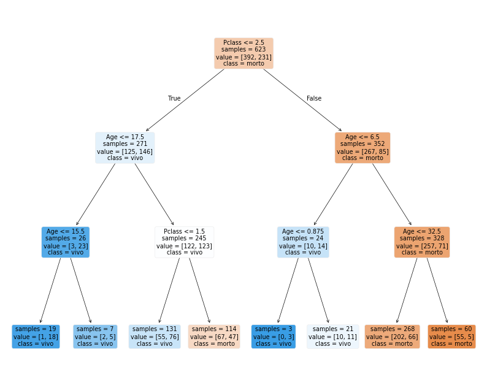

```python
# Importare le librerie per la visualizzazione
    from sklearn.tree import plot_tree
    import matplotlib.pyplot as plt

    # Visualizzare l'albero decisionale con dimensioni ridotte e senza impurità
    plt.figure(figsize=(10, 8))  # Dimensione ridotta del grafico
    plot_tree(
        model,
        feature_names=X.columns,
        class_names=['morto', 'vivo'],
        filled=True,
        impurity=False,
        rounded=True
    )
    plt.show()
```